# Homework-5

Shiying Wang

12/16/2018

## Question 1

Firstly, we use LASSO to predict hand-writing characters in MNIST dataset.

```r
library(glmnet)

#data preparation
mnist <- dataset_mnist()
x_train <- mnist$train$x
y_train <- mnist$train$y
x_test <- mnist$test$x
y_test <- mnist$test$y

x_train <- array_reshape(x_train, c(60000, 28^2))
x_test <- array_reshape(x_test, c(10000, 28^2))
y_train <- factor(y_train)
y_test <- factor(y_test)

# we only randomly select 1000 samples to fit model, or it will take too much time
s <- sample(seq_along(y_train), 1000)
fit <- cv.glmnet(x_train[s,], y_train[s], family = "multinomial")

#calculate out-of-sample prediction accuracy
preds_out <- predict(fit$glmnet.fit, x_test, s = fit$lambda.min,
                 type = "class")
t <- table(as.vector(preds_out), y_test)
sum(diag(t)) / sum(t)
```

The out-of-sample accuracy rate is 0.8526.

```r
library(keras)
# Data Preparation
batch_size <- 128
num_classes <- 10
epochs <- 2

# Input image dimensions
img_rows <- 28
img_cols <- 28

# The data, shuffled and split between train and test sets
mnist <- dataset_mnist()
x_train <- mnist$train$x
y_train <- mnist$train$y
x_test <- mnist$test$x
y_test <- mnist$test$y

# Redefine  dimension of train/test inputs
x_train <- array_reshape(x_train, c(nrow(x_train), img_rows, img_cols, 1))
x_test <- array_reshape(x_test, c(nrow(x_test), img_rows, img_cols, 1))
input_shape <- c(img_rows, img_cols, 1)

# Transform RGB values into [0,1] range
x_train <- x_train / 255
x_test <- x_test / 255

cat('x_train_shape:', dim(x_train), '\n')
cat(nrow(x_train), 'train samples\n')
cat(nrow(x_test), 'test samples\n')

# Convert class vectors to binary class matrices
y_train <- to_categorical(y_train, num_classes)
y_test <- to_categorical(y_test, num_classes)

# Define Model ----------------------------------------------------------

# Define model
model <- keras_model_sequential() %>%
  layer_conv_2d(filters = 32, kernel_size = c(3,3), activation = 'relu',
                input_shape = input_shape) %>%
  layer_conv_2d(filters = 64, kernel_size = c(3,3), activation = 'relu') %>%
  layer_max_pooling_2d(pool_size = c(2, 2)) %>%

  layer_dropout(rate = 0.25) %>%
  layer_flatten() %>%
  layer_dense(units = 128, activation = 'relu') %>%
  layer_dense(units = 128, activation = 'relu') %>%
  layer_dropout(rate = 0.5) %>%
  layer_dense(units = num_classes, activation = 'softmax')

# Compile model
model %>% compile(
  loss = loss_categorical_crossentropy,
  optimizer = optimizer_adadelta(),
  metrics = c('accuracy')
)

# Train model
model %>% fit(
  x_train, y_train,
  batch_size = batch_size,
  epochs = epochs,
  validation_split = 0.2
)

scores <- model %>% evaluate(
  x_test, y_test, verbose = 0
)
scores
```

The out-of-sample accuracy rate is 0.9857.  
Neural network method achieves much higher out-of-sample prediction accuracy rate. Neural network method extracts more features from imaging data. Only using a part of sample for LASSO method also partially explain this result.

## Question 2

Load the EMNIST letters dataset into R. Data Preparation:

```r
x_train <- emnist$train$x
y_train <-emnist$train$y
x_test <- emnist$test$x
y_test <- emnist$test$y
batch_size <- 128
num_classes <- 26
epochs <- 2
# Input image dimensions
img_rows <- 28
img_cols <- 28

x_train <- array_reshape(x_train, c(nrow(x_train), img_rows, img_cols, 1))
x_test <- array_reshape(x_test, c(nrow(x_test), img_rows, img_cols, 1))
input_shape <- c(img_rows, img_cols, 1)

# Transform RGB values into [0,1] range
x_train <- x_train / 255
x_test <- x_test / 255
cat('x_train_shape:', dim(x_train), '\n')
cat(nrow(x_train), 'train samples\n')
cat(nrow(x_test), 'test samples\n')

# Convert class vectors to binary class matrices
y_train <- to_categorical(y_train-1, num_classes)
y_test <- to_categorical(y_test-1, num_classes)
```

Define model:  
The neural network model includes 4 convolutional layers, 2 pooling layers and 3 fully connected layers.

# Model 1

For each convolution layer, filters=32, kernal size=c(2,2), and for each fully connected layer, units=128.

```r
model<- keras_model_sequential()
model %>%
  layer_conv_2d(filters = 32, kernel_size = c(2,2),
                input_shape = c(28, 28, 1),
                padding = "same") %>%
  layer_activation(activation = "relu") %>%
  layer_conv_2d(filters = 32, kernel_size = c(2,2),
                padding = "same") %>%
  layer_activation(activation = "relu") %>%
  layer_max_pooling_2d(pool_size = c(2, 2)) %>%
  layer_dropout(rate = 0.5) %>%
  layer_conv_2d(filters = 32, kernel_size = c(2,2),
                padding = "same") %>%
  layer_activation(activation = "relu") %>%
  layer_conv_2d(filters = 32, kernel_size = c(2,2),
                padding = "same") %>%
  layer_activation(activation = "relu") %>%
  layer_max_pooling_2d(pool_size = c(2, 2)) %>%
  layer_dropout(rate = 0.5) %>%
  layer_flatten() %>%
  layer_dense(units = 128) %>%
  layer_activation(activation = "relu") %>%
  layer_dense(units = 128) %>%
  layer_activation(activation = "relu") %>%
  layer_dropout(rate = 0.5) %>%
  layer_dense(units = 26) %>%
  layer_activation(activation = "softmax")

model %>% compile(loss = 'categorical_crossentropy',
                  optimizer = optimizer_rmsprop(),
                  metrics = c('accuracy'))

history <- model %>%
  fit(x_train, y_train, epochs = 2,
      batch_size = batch_size,
      validation_split = 0.2)

scores_train <- model %>% evaluate(
  x_train, y_train, verbose = 0
)
scores_test <- model %>% evaluate(
  x_test, y_test, verbose = 0
)
scores_test
scores_train
```

# Model 2

Set a different kernal size for convolution layers from model 1.  
For each convolution layer, filters=32, kernal size=c(3,3), and for each fully connected layer, units=128.

```r
model <- keras_model_sequential()
model %>%
  layer_conv_2d(filters = 32, kernel_size = c(3,3),
                input_shape = c(28, 28, 1),
                padding = "same") %>%
  layer_activation(activation = "relu") %>%
  layer_conv_2d(filters = 32, kernel_size = c(3,3),
                padding = "same") %>%
  layer_activation(activation = "relu") %>%
  layer_max_pooling_2d(pool_size = c(2, 2)) %>%
  layer_dropout(rate = 0.5) %>%
  layer_conv_2d(filters = 32, kernel_size = c(3,3),
                padding = "same") %>%
  layer_activation(activation = "relu") %>%
  layer_conv_2d(filters = 32, kernel_size = c(3,3),
                padding = "same") %>%
  layer_activation(activation = "relu") %>%
  layer_max_pooling_2d(pool_size = c(2, 2)) %>%
  layer_dropout(rate = 0.5) %>%
  layer_flatten() %>%
  layer_dense(units = 128) %>%
  layer_activation(activation = "relu") %>%
  layer_dense(units = 128) %>%
  layer_activation(activation = "relu") %>%
  layer_dropout(rate = 0.5) %>%
  layer_dense(units = 26) %>%
  layer_activation(activation = "softmax")

model %>% compile(loss = 'categorical_crossentropy',
                  optimizer = optimizer_rmsprop(),
                  metrics = c('accuracy'))

history2 <- model %>%
  fit(x_train, y_train, epochs = 2,
      batch_size = batch_size,
      validation_split = 0.2)

scores2_train <- model %>% evaluate(
  x_train, y_train, verbose = 0
)
scores2_test <- model %>% evaluate(
  x_test, y_test, verbose = 0
)
scores2_test
scores2_train
```

# Model 3

Set a different filters number for convolution layers from model 1.  
For each convolution layer, filters=64, kernal size=c(2,2), and for each dense layer, units=128

```r
model<- keras_model_sequential()
model %>%
  layer_conv_2d(filters = 64, kernel_size = c(2,2),
                input_shape = c(28, 28, 1),
                padding = "same") %>%
  layer_activation(activation = "relu") %>%
  layer_conv_2d(filters = 64, kernel_size = c(2,2),
                padding = "same") %>%
  layer_activation(activation = "relu") %>%
  layer_max_pooling_2d(pool_size = c(2, 2)) %>%
  layer_dropout(rate = 0.5) %>%
  layer_conv_2d(filters = 64, kernel_size = c(2,2),
                padding = "same") %>%
  layer_activation(activation = "relu") %>%
  layer_conv_2d(filters = 64, kernel_size = c(2,2),
                padding = "same") %>%
  layer_activation(activation = "relu") %>%
  layer_max_pooling_2d(pool_size = c(2, 2)) %>%
  layer_dropout(rate = 0.5) %>%
  layer_flatten() %>%
  layer_dense(units = 128) %>%
  layer_activation(activation = "relu") %>%
  layer_dense(units = 128) %>%
  layer_activation(activation = "relu") %>%
  layer_dropout(rate = 0.5) %>%
  layer_dense(units = 26) %>%
  layer_activation(activation = "softmax")

model %>% compile(loss = 'categorical_crossentropy',
                  optimizer = optimizer_rmsprop(),
                  metrics = c('accuracy'))

history3 <- model %>%
  fit(x_train, y_train, epochs = 2,
      batch_size = batch_size,
      validation_split = 0.2)

scores3_train <- model %>% evaluate(
  x_train, y_train, verbose = 0
)
scores3_test <- model %>% evaluate(
  x_test, y_test, verbose = 0
)
scores3_test
scores3_train
```

# Model 4

Set a different unitA number for dense layers from model 1.  
For each convolution layer, filters=32, kernal size=c(2,2), and for each fully connected layer, units=256.

```r
model<- keras_model_sequential()
model %>%
  layer_conv_2d(filters = 32, kernel_size = c(2,2),
                input_shape = c(28, 28, 1),
                padding = "same") %>%
  layer_activation(activation = "relu") %>%
  layer_conv_2d(filters = 32, kernel_size = c(2,2),
                padding = "same") %>%
  layer_activation(activation = "relu") %>%
  layer_max_pooling_2d(pool_size = c(2, 2)) %>%
  layer_dropout(rate = 0.5) %>%
  layer_conv_2d(filters = 32, kernel_size = c(2,2),
                padding = "same") %>%
  layer_activation(activation = "relu") %>%
  layer_conv_2d(filters = 32, kernel_size = c(2,2),
                padding = "same") %>%
  layer_activation(activation = "relu") %>%
  layer_max_pooling_2d(pool_size = c(2, 2)) %>%
  layer_dropout(rate = 0.5) %>%
  layer_flatten() %>%
  layer_dense(units = 256) %>%
  layer_activation(activation = "relu") %>%
  layer_dense(units = 256) %>%
  layer_activation(activation = "relu") %>%
  layer_dropout(rate = 0.5) %>%
  layer_dense(units = 26) %>%
  layer_activation(activation = "softmax")

model %>% compile(loss = 'categorical_crossentropy',
                  optimizer = optimizer_rmsprop(),
                  metrics = c('accuracy'))

history4 <- model %>%
  fit(x_train, y_train, epochs = 2,
      batch_size = batch_size,
      validation_split = 0.2)

scores4_train <- model %>% evaluate(
  x_train, y_train, verbose = 0
)
scores4_test <- model %>% evaluate(
  x_test, y_test, verbose = 0
)
scores4_test
scores4_train
```

The train accuracy and test accuracy for 4 models:

```
##         train accuracy test accuracy
## Model 1      0.9077244     0.9045673
## Model 2      0.9237740     0.9189904
## Model 3      0.9229560     0.9187019
## Model 4      0.9225401     0.9182692
```

Increasing the kernal size, filters number in convolution layers and units number in fully connected layers can increase the training and testing accuracy rate.

## Question 3

```r
# Create list of weights to describe a dense neural network.
#
# Args:
#     sizes: A vector giving the size of each layer, including
#             the input and output layers.
#
# Returns:
#     A list containing initialized weights and biases.
casl_nn_make_weights <-function(sizes)
{
  L <- length(sizes) - 1L
  weights <- vector("list", L)
  for (j in seq_len(L))
  {
    w <- matrix(rnorm(sizes[j] * sizes[j + 1L]),
                ncol = sizes[j],
                nrow = sizes[j + 1L])
    weights[[j]] <- list(w=w,
                         b=rnorm(sizes[j + 1L]))
  }
  weights }

# Apply a rectified linear unit (ReLU) to a vector/matrix.
#
# Args:
#     v: A numeric vector or matrix.
#
# Returns:#     The original input with negative values truncated to zero.
casl_util_ReLU <-function(v)
  {
    v[v < 0] <- 0
    v }

# Apply derivative of the rectified linear unit (ReLU).
#
# Args:
#     v: A numeric vector or matrix.
#
# Returns:
#     Sets positive values to 1 and negative values to zero.
casl_util_ReLU_p <- function(v)
  {
    p <- v * 0
    p[v > 0] <- 1
    p
  }
```

Derivative of two kinds of loss function: MAD and MSE

```r
# Derivative of the mean absolute deviation (MAD) function.
#
# Args:
#     y: A numeric vector of responses.
#     a: A numeric vector of predicted responses.
#
# Returns:
#     Returned current derivative the MAD function.
casl_util_mad_p <-function(y, a)
  { if (y>a)  -1
    else 1
     }
# Derivative of the mean squared error (MSE) function.
#
# Args:
#     y: A numeric vector of responses.
#     a: A numeric vector of predicted responses.
#
# Returns:
#     Returned current derivative the MSE function.
casl_util_mse_p <-function(y, a)
  {
    (a - y) }
```

```r
# Apply forward propagation to a set of NN weights and biases.
#
# Args:
#     x: A numeric vector representing one row of the input.
#     weights: A list created by casl_nn_make_weights.
#     sigma: The activation function.
#
# Returns:
#     A list containing the new weighted responses (z) and
#     activations (a).
casl_nn_forward_prop <-function(x, weights, sigma)
  {
    L <- length(weights)
    z <- vector("list", L)
    a <- vector("list", L)
    for (j in seq_len(L))
    {
      a_j1 <- if(j == 1) x else a[[j - 1L]]
      z[[j]] <- weights[[j]]$w %*% a_j1 + weights[[j]]$b
      a[[j]] <- if (j != L) sigma(z[[j]]) else z[[j]]
    }
    list(z=z, a=a)
  }

# Apply backward propagation algorithm.
#
# Args:
#     x: A numeric vector representing one row of the input.
#     y: A numeric vector representing one row of the response.
#     weights: A list created by casl_nn_make_weights.
#     f_obj: Output of the function casl_nn_forward_prop.
#     sigma_p: Derivative of the activation function.
#     f_p: Derivative of the loss function.
#
# Returns:
#     A list containing the new weighted responses (z) and
#     activations (a).
casl_nn_backward_prop <-function(x, y, weights, f_obj, sigma_p, f_p)
  {
    z <- f_obj$z; a <- f_obj$a
    L <- length(weights)
    grad_z <- vector("list", L)
    grad_w <- vector("list", L)
    for (j in rev(seq_len(L)))
    {
      if (j == L) {
        grad_z[[j]] <- f_p(y, a[[j]])
      } else {
        grad_z[[j]] <- (t(weights[[j + 1]]$w) %*%
                          grad_z[[j + 1]]) * sigma_p(z[[j]])
      }
      a_j1 <- if(j == 1) x else a[[j - 1L]]
      grad_w[[j]] <- grad_z[[j]] %*% t(a_j1)
    }
    list(grad_z=grad_z, grad_w=grad_w)
  }
```

Two kinds of SGD functions:

```r
# Apply stochastic gradient descent (SGD) to estimate NN using MSE as loss function.
#
# Args:
#     X: A numeric data matrix.
#     y: A numeric vector of responses.
#     sizes: A numeric vector giving the sizes of layers in
#            the neural network.
#     epochs: Integer number of epochs to computer.
#     eta: Positive numeric learning rate.
#     weights: Optional list of starting weights.
#
# Returns:
#     A list containing the trained weights for the network.
casl_nn_sgd_mse <-function(X, y, sizes, epochs, eta, weights=NULL)
{if (is.null(weights))
{
  weights <- casl_nn_make_weights(sizes)
}
for (epoch in seq_len(epochs))
{
  for (i in seq_len(nrow(X)))
  {
    f_obj <- casl_nn_forward_prop(X[i,], weights,
casl_util_ReLU)
b_obj <- casl_nn_backward_prop(X[i,], y[i,], weights,
f_obj, casl_util_ReLU_p,
casl_util_mse_p)
for (j in seq_along(b_obj))
{
  weights[[j]]$b <- weights[[j]]$b -
                      eta * b_obj$grad_z[[j]]
  weights[[j]]$w <- weights[[j]]$w -
eta * b_obj$grad_w[[j]]
}
} }
weights }

# Apply stochastic gradient descent (SGD) to estimate NN using MAD as loss function.
#
# Args:
#     X: A numeric data matrix.
#     y: A numeric vector of responses.
#     sizes: A numeric vector giving the sizes of layers in
#            the neural network.
#     epochs: Integer number of epochs to computer.
#     eta: Positive numeric learning rate.
#     weights: Optional list of starting weights.
#
# Returns:
#     A list containing the trained weights for the network.
casl_nn_sgd_mad <-function(X, y, sizes, epochs, eta, weights=NULL)
{if (is.null(weights))
{
  weights <- casl_nn_make_weights(sizes)
}
for (epoch in seq_len(epochs))
{
  for (i in seq_len(nrow(X)))
  {
    f_obj <- casl_nn_forward_prop(X[i,], weights,
casl_util_ReLU)
b_obj <- casl_nn_backward_prop(X[i,], y[i,], weights,
f_obj, casl_util_ReLU_p,
casl_util_mad_p)
for (j in seq_along(b_obj))
{
  weights[[j]]$b <- weights[[j]]$b -
                      eta * b_obj$grad_z[[j]]
  weights[[j]]$w <- weights[[j]]$w -
eta * b_obj$grad_w[[j]]
}
} }
weights }

# Predict values from a training neural network.
#
# Args:
#     weights: List of weights describing the neural network.
#     X_test: A numeric data matrix for the predictions.
#
# Returns:
#     A matrix of predicted values.
casl_nn_predict <-function(weights, X_test)
  {
    p <- length(weights[[length(weights)]]$b)
    y_hat <- matrix(0, ncol = p, nrow = nrow(X_test))
    for (i in seq_len(nrow(X_test)))
    {
      a <- casl_nn_forward_prop(X_test[i,], weights,
                                casl_util_ReLU)$a
      y_hat[i, ] <- a[[length(a)]]
    }
    y_hat }
```

Data simulation:

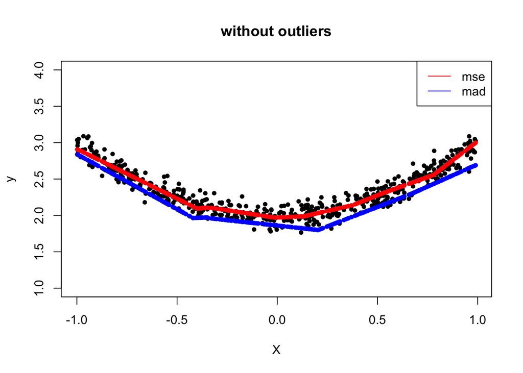

```r
set.seed(666)
# without outliers
X <- matrix(runif(500, min=-1, max=1), ncol=1)
y <- 2+X[,1,drop = FALSE]^2 + rnorm(500, sd = 0.1)
weights1<-casl_nn_sgd_mse(X, y, sizes=c(1, 25, 1), epochs=25, eta=0.01)
weights2<-casl_nn_sgd_mad(X, y, sizes=c(1, 25, 1),epochs=25, eta=0.01)
y_pred_mse <- casl_nn_predict(weights1, X)
y_pred_mad <- casl_nn_predict(weights2, X)
plot(X,y, pch=20,ylim=c(1,4), main="without outliers")
points(X,y_pred_mse,col="red",pch=20)
points(X,y_pred_mad,col="blue",pch=20)
legend("topright",legend=c("mse","mad"),lty=1,col=c("red","blue"))
```

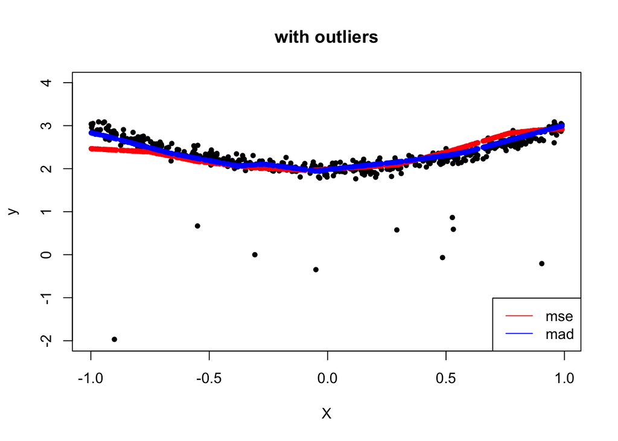

```r
# with outliers
set.seed(666)
X <- matrix(runif(500, min=-1, max=1), ncol=1)
y <- 2+X[,1,drop = FALSE]^2 + rnorm(500, sd = 0.1)
y[sample(1:500, 10)]<- rnorm(10, sd = 1)
weights1 <- casl_nn_sgd_mse(X, y, sizes=c(1, 25, 1),epochs=25, eta=0.01)
weights2 <- casl_nn_sgd_mad(X, y, sizes=c(1, 25, 1),epochs=25, eta=0.01)
y_pred_mse <- casl_nn_predict(weights1, X)
y_pred_mad <- casl_nn_predict(weights2, X)

plot(X,y, pch=20,ylim=c(-2,4),main="with outliers")
points(X,y_pred_mse,col="red",pch=20)
points(X,y_pred_mad,col="blue",pch=20)
legend("bottomright",legend=c("mse","mad"),lty=1,col=c("red","blue"))
```